# Tugas Pertemuan 3 - Regresi dengan Peubah Lag

# 1. Persiapan Library

```r
library(dLagM)
library(dynlm)
library(MLmetrics)
library(lmtest)
library(car)
library(rio)
```

# 2. Impor dan Persiapan Data

```r
data <- rio::import("NewDelhi_Air_quality.csv")

# Memilih variabel
data <- data[, c("AQI", "pm25")]

# Hapus missing value
data <- na.omit(data)

# Memastikan tipe data numerik
data$AQI <- as.numeric(data$AQI)
data$pm25 <- as.numeric(data$pm25)

str(data)
```

```
## 'data.frame':    72 obs. of  2 variables:
##  $ AQI : num  30.2 28.2 26.6 25 26 26 26 24 23 24 ...
##  $ pm25: num  5.64 4.62 3.52 2.23 1.98 ...
```

```r
summary(data)
```

```
##       AQI             pm25
##  Min.   :19.00   Min.   :1.633
##  1st Qu.:25.00   1st Qu.:1.829
##  Median :27.00   Median :2.202
##  Mean   :26.18   Mean   :2.295
##  3rd Qu.:28.00   3rd Qu.:2.522
##  Max.   :32.00   Max.   :5.637
```

```r
head(data)
```

|  | AQI | pm25 |
| --- | --- | --- |
| 1 | 30.2 | 5.637410 |
| 2 | 28.2 | 4.618169 |
| 3 | 26.6 | 3.520902 |
| 4 | 25.0 | 2.225919 |
| 5 | 26.0 | 1.979471 |
| 6 | 26.0 | 1.792677 |

```r
n <- nrow(data)
n_train <- floor(0.80 * n)

train <- data[1:n_train, ]
test <- data[(n_train + 1):n, ]

train.ts <- ts(train)
test.ts <- ts(test)
data.ts <- ts(data)

nrow(train)
```

```
## [1] 57
```

```r
nrow(test)
```

```
## [1] 15
```

# 3. Model Koyck

```r
model.koyck <- koyckDlm(
  x = train$pm25,
  y = train$AQI
)

summary(model.koyck)
```

```
##
## Call:
## "Y ~ (Intercept) + Y.1 + X.t"
##
## Residuals:
##      Min       1Q   Median       3Q      Max
## -2.19768 -0.57669 -0.03615  0.58158  2.18318
##
## Coefficients:
##             Estimate Std. Error t value Pr(>|t|)
## (Intercept)  4.54910    1.77579   2.562   0.0133 *
## Y.1          0.87326    0.05731  15.237   <2e-16 ***
## X.t         -0.56825    0.27658  -2.055   0.0449 *
## ---
## Signif. codes:  0 '***' 0.001 '**' 0.01 '*' 0.05 '.' 0.1 ' ' 1
##
## Residual standard error: 0.8986 on 53 degrees of freedom
## Multiple R-Squared: 0.8303,  Adjusted R-squared: 0.8239
## Wald test: 129.9 on 2 and 53 DF,  p-value: < 2.2e-16
##
## Diagnostic tests:
## NULL
##
##                             alpha       beta      phi
## Geometric coefficients:  35.89204 -0.5682546 0.873256
```

## Peramalan Koyck

```r
h <- nrow(test)

fore.koyck <- forecast(
  model = model.koyck,
  x = test$pm25,
  h = h
)

fore.koyck
```

```
## $forecasts
##  [1] 24.95927 24.78189 24.49412 24.19650 23.90670 23.66965 23.52745 23.47683
##  [9] 23.47525 23.49718 23.52224 23.54830 23.55405 23.53805 23.54349
##
## $call
## forecast.koyckDlm(model = model.koyck, x = test$pm25, h = h)
##
## attr(,"class")
## [1] "forecast.koyckDlm" "dLagM"
```

```r
mape.koyck <- MAPE(fore.koyck$forecasts, test$AQI)
deviance.koyck <- sum(residuals(model.koyck)^2)
```

[output not shown]

```r
cat("MAPE Koyck:", mape.koyck, "\n")
```

```
## MAPE Koyck: 0.1394956
```

```r
cat("Deviance Koyck:", deviance.koyck, "\n")
```

```
## Deviance Koyck: 42.79538
```

# 4. Distributed Lag Model (DLM)

```r
dlm.opt <- finiteDLMauto(
  formula = AQI ~ pm25,
  data = train,
  q.min = 1,
  q.max = 10,
  model.type = "dlm",
  error.type = "AIC",
  trace = TRUE
)

dlm.opt
```

|  | q - k | MASE | AIC | BIC | GMRAE | MBRAE | R.Adj.Sq | Ljung-Box |
| --- | --- | --- | --- | --- | --- | --- | --- | --- |
| 10 | 10 | 1.79180 | 181.4052 | 205.4571 | 69409.72 | 1.83368 | 0.50588 | 4.814509e-08 |
| 9 | 9 | 1.95552 | 192.2161 | 214.6706 | 59217.09 | -0.65007 | 0.43896 | 3.162063e-08 |
| 8 | 8 | 2.01622 | 196.5406 | 217.3506 | 51171.73 | 0.67925 | 0.46088 | 2.929916e-10 |
| 7 | 7 | 1.96730 | 197.4880 | 216.6082 | 40347.66 | 0.63118 | 0.49602 | 6.697151e-10 |
| 6 | 6 | 1.83971 | 198.5178 | 215.9042 | 28047.21 | 0.57217 | 0.50809 | 5.471995e-10 |
| 5 | 5 | 1.86028 | 201.4950 | 217.1050 | 31164.02 | -0.91742 | 0.50052 | 9.449556e-10 |
| 4 | 4 | 1.97485 | 207.2937 | 221.0857 | 40854.21 | 0.73804 | 0.46486 | 3.806880e-09 |
| 3 | 3 | 2.24020 | 217.2830 | 229.2169 | 49384.27 | 0.80165 | 0.38957 | 1.527662e-09 |
| 2 | 2 | 2.28777 | 229.4667 | 239.5034 | 38705.59 | 1.30509 | 0.26580 | 9.176708e-07 |
| 1 | 1 | 2.37966 | 242.0647 | 250.1661 | 31042.32 | 0.66469 | 0.11843 | 2.695019e-09 |

AIC terkecil diperoleh pada **q = 10**.

```r
q.dlm.opt <- 10

model.dlm.opt <- dlm(
  x = train$pm25,
  y = train$AQI,
  q = q.dlm.opt
)

summary(model.dlm.opt)
```

```
##
## Call:
## lm(formula = model.formula, data = design)
##
## Residuals:
##      Min       1Q   Median       3Q      Max
## -2.71041 -0.83916  0.09733  0.83799  2.91674
##
## Coefficients:
##             Estimate Std. Error t value Pr(>|t|)
## (Intercept)   40.971      2.293  17.869  < 2e-16 ***
## x.t          -20.622      6.211  -3.320  0.00211 **
## x.1           13.567     13.579   0.999  0.32458
## x.2            5.848     16.535   0.354  0.72570
## x.3           -1.330     15.861  -0.084  0.93363
## x.4           -2.878     15.189  -0.190  0.85079
## x.5           -4.771     14.732  -0.324  0.74798
## x.6           16.900     12.053   1.402  0.16968
## x.7          -18.277      6.733  -2.714  0.01024 *
## x.8            3.422      4.514   0.758  0.45342
## x.9            6.711      4.327   1.551  0.12987
## x.10          -5.245      2.067  -2.537  0.01579 *
## ---
## Signif. codes:  0 '***' 0.001 '**' 0.01 '*' 0.05 '.' 0.1 ' ' 1
##
## Residual standard error: 1.465 on 35 degrees of freedom
## Multiple R-squared:  0.624,  Adjusted R-squared:  0.5059
## F-statistic: 5.281 on 11 and 35 DF,  p-value: 7.336e-05
##
## AIC and BIC values for the model:
##        AIC      BIC
## 1 181.4052 205.4571
```

## Peramalan DLM

```r
fore.dlm <- forecast(
  model = model.dlm.opt,
  x = test$pm25,
  h = h
)

fore.dlm
```

```
## $forecasts
##  [1] 20.07737 18.62323 20.17446 21.75975 21.26503 22.99841 25.77936 25.15035
##  [9] 24.78707 22.94875 23.25511 23.14383 21.34264 21.15855 23.01784
##
## $call
## forecast.dlm(model = model.dlm.opt, x = test$pm25, h = h)
##
## attr(,"class")
## [1] "forecast.dlm" "dLagM"
```

```r
mape.dlm <- MAPE(fore.dlm$forecasts, test$AQI)
deviance.dlm <- sum(residuals(model.dlm.opt)^2)
```

[output not shown]

```r
cat("MAPE DLM:", mape.dlm, "\n")
```

```
## MAPE DLM: 0.144226
```

```r
cat("Deviance DLM:", deviance.dlm, "\n")
```

```
## Deviance DLM: 75.09572
```

# 5. Autoregressive Distributed Lag (ARDL)

```r
model.ardl.opt <- ardlBoundOrders(
  data = data.frame(train),
  ic = "AIC",
  formula = AQI ~ pm25
)

model.ardl.opt
```

```
## $p
##   pm25
## 1   15
##
## $q
## [1] 15
##
## $Stat.table
##            q = 1     q = 2     q = 3     q = 4     q = 5     q = 6     q = 7
## p = 1  140.96343 138.54505 132.99479 123.55712 123.90746 121.40329 114.20470
## p = 2  138.30775 138.82888 133.62202 125.54055 122.61537 113.66417 110.25671
## p = 3  134.13415 134.13415 135.57031 127.54040 123.92956 109.44506 108.85286
## p = 4  118.62364 120.57981 120.57981 122.23541 118.24755 108.18873 107.94733
## p = 5  114.71656 116.67961 117.27554 117.27554 118.92580 107.57522 107.98734
## p = 6  105.13284 107.11324 106.83109 108.05850 108.05850 108.76605 109.57530
## p = 7  113.19250 114.39875 111.17772 109.69456 107.88697 107.88697 109.84485
## p = 8   99.79025 101.61094 101.74121 100.88003  99.95660 100.94338 100.94338
## p = 9   88.49074  87.80524  87.86929  87.07306  84.78252  85.59977  87.48566
## p = 10  86.43195  87.60610  79.65714  80.53203  75.84789  77.48558  79.48413
## p = 11  99.27857  99.31693  92.92575  89.35067  80.26855  81.79503  83.18196
## p = 12 108.14062 103.51519  96.04352  93.91544  85.18422  86.33714  87.72503
## p = 13 109.41507 103.52229  97.67071  96.32837  84.85661  86.34649  87.75378
## p = 14 110.00106  99.71683  90.89914  88.67776  80.05991  81.35374  82.29160
## p = 15 105.27088 102.33304  93.63709  90.76521  76.56629  78.21673  79.71004
##            q = 8     q = 9    q = 10    q = 11    q = 12    q = 13    q = 14
## p = 1  114.80886 115.64636 112.72216 110.41750 107.81635 101.64925 102.38914
## p = 2  110.14509 109.79120 110.10406 106.63492  96.60230  96.08167  94.63556
## p = 3  109.20134 109.47553 108.92528 105.24575  92.56052  94.12554  94.29542
## p = 4  108.22520 108.75388 108.92572 107.16073  93.37342  95.07484  95.97208
## p = 5  103.26125 101.39410 101.10826  95.87093  87.21504  87.01273  88.31178
## p = 6  103.66223 101.94872  99.21396  94.78001  78.08871  73.27211  71.86812
## p = 7  105.11176 102.48079  96.50323  92.27520  79.50622  73.57054  70.44913
## p = 8  102.41321  98.42151  95.19426  92.91922  80.21984  71.48090  70.36811
## p = 9   87.48566  88.36519  79.51468  78.93501  78.20636  73.45340  72.11225
## p = 10  79.62153  79.62153  81.49450  80.77921  80.13557  75.00996  73.76570
## p = 11  81.80315  81.98892  81.98892  82.01082  81.60699  76.34906  69.90165
## p = 12  84.43373  82.29121  83.09421  83.09421  80.77141  75.20715  69.42366
## p = 13  83.75021  82.90930  84.84889  83.00204  83.00204  76.18047  65.30612
## p = 14  79.15810  74.31320  76.30929  71.90703  73.73493  73.73493  67.11178
## p = 15  71.16979  61.35428  58.67383  54.61943  55.55869  54.32641  54.32641
##          q = 15
## p = 1  98.88454
## p = 2  92.20168
## p = 3  88.90993
## p = 4  90.88714
## p = 5  88.20222
## p = 6  74.14324
## p = 7  71.14269
## p = 8  71.98584
## p = 9  73.94256
## p = 10 74.62778
## p = 11 72.56672
## p = 12 62.57944
## p = 13 56.90483
## p = 14 55.15744
## p = 15 55.83027
##
## $min.Stat
## [1] 54.32641
```

```r
p.ardl.opt <- 14
q.ardl.opt <- 15

model.ardl <- ardlDlm(
  formula = AQI ~ pm25,
  data = train,
  p = p.ardl.opt,
  q = q.ardl.opt
)

summary(model.ardl)
```

```
##
## Time series regression with "ts" data:
## Start = 16, End = 57
##
## Call:
## dynlm(formula = as.formula(model.text), data = data)
##
## Residuals:
##      Min       1Q   Median       3Q      Max
## -0.53200 -0.10093  0.01635  0.09676  0.65573
##
## Coefficients:
##              Estimate Std. Error t value Pr(>|t|)
## (Intercept)  59.78067   22.08236   2.707   0.0204 *
## pm25.t      -10.98819    4.08523  -2.690   0.0210 *
## pm25.1        5.36311    7.52430   0.713   0.4908
## pm25.2        4.20675    8.57936   0.490   0.6335
## pm25.3        4.69004    9.01060   0.521   0.6130
## pm25.4      -10.13661    9.28243  -1.092   0.2982
## pm25.5        5.45032   10.00048   0.545   0.5966
## pm25.6        7.19855    8.76128   0.822   0.4287
## pm25.7       -4.83698    8.28638  -0.584   0.5712
## pm25.8       -6.17899    8.08108  -0.765   0.4606
## pm25.9       -1.07300    8.32142  -0.129   0.8997
## pm25.10      -1.41462    7.18315  -0.197   0.8475
## pm25.11       3.35441    6.05282   0.554   0.5905
## pm25.12      -4.25931    4.20043  -1.014   0.3324
## pm25.13       1.88326    2.71617   0.693   0.5025
## pm25.14      -2.17543    1.65645  -1.313   0.2158
## AQI.1        -0.08608    0.27228  -0.316   0.7578
## AQI.2         0.36114    0.25518   1.415   0.1847
## AQI.3         0.25665    0.28665   0.895   0.3898
## AQI.4        -0.16645    0.25755  -0.646   0.5313
## AQI.5         0.03455    0.24495   0.141   0.8904
## AQI.6        -0.24281    0.25081  -0.968   0.3538
## AQI.7         0.10275    0.24283   0.423   0.6803
## AQI.8         0.11302    0.23295   0.485   0.6371
## AQI.9        -0.19672    0.22306  -0.882   0.3967
## AQI.10       -0.44024    0.23863  -1.845   0.0921 .
## AQI.11       -0.29035    0.26074  -1.114   0.2892
## AQI.12        0.24956    0.26053   0.958   0.3587
## AQI.13        0.20589    0.26640   0.773   0.4559
## AQI.14       -0.07134    0.29077  -0.245   0.8107
## AQI.15       -0.35888    0.19547  -1.836   0.0935 .
## ---
## Signif. codes:  0 '***' 0.001 '**' 0.01 '*' 0.05 '.' 0.1 ' ' 1
##
## Residual standard error: 0.4802 on 11 degrees of freedom
## Multiple R-squared:  0.9864, Adjusted R-squared:  0.9493
## F-statistic: 26.59 on 30 and 11 DF,  p-value: 9.957e-07
```

## Peramalan ARDL

```r
fore.ardl <- forecast(
  model = model.ardl,
  x = test$pm25,
  h = h
)

fore.ardl
```

```
## $forecasts
##  [1] 20.70635 19.49850 19.88283 20.68326 21.06081 22.88450 26.20181 28.45780
##  [9] 27.58107 27.04839 27.34369 26.95260 23.30264 21.57340 21.26209
##
## $call
## forecast.ardlDlm(model = model.ardl, x = test$pm25, h = h)
##
## attr(,"class")
## [1] "forecast.ardlDlm" "dLagM"
```

```r
mape.ardl <- MAPE(fore.ardl$forecasts, test$AQI)
deviance.ardl <- sum(residuals(model.ardl)^2)
```

[output not shown]

```r
cat("MAPE ARDL:", mape.ardl, "\n")
```

```
## MAPE ARDL: 0.1861078
```

```r
cat("Deviance ARDL:", deviance.ardl, "\n")
```

```
## Deviance ARDL: 2.536767
```

# 6. Uji Asumsi

```r
cons_lm1 <- dynlm(
  AQI ~ pm25 + L(pm25),
  data = train.ts
)

summary(cons_lm1)
```

```
##
## Time series regression with "ts" data:
## Start = 2, End = 57
##
## Call:
## dynlm(formula = AQI ~ pm25 + L(pm25), data = train.ts)
##
## Residuals:
##     Min      1Q  Median      3Q     Max
## -4.8774 -1.3623 -0.4143  0.9707  4.3977
##
## Coefficients:
##             Estimate Std. Error t value Pr(>|t|)
## (Intercept)   31.354      1.426  21.986  < 2e-16 ***
## pm25          -4.509      1.644  -2.744  0.00828 **
## L(pm25)        2.431      1.161   2.095  0.04098 *
## ---
## Signif. codes:  0 '***' 0.001 '**' 0.01 '*' 0.05 '.' 0.1 ' ' 1
##
## Residual standard error: 2.011 on 53 degrees of freedom
## Multiple R-squared:  0.1505, Adjusted R-squared:  0.1184
## F-statistic: 4.694 on 2 and 53 DF,  p-value: 0.01328
```

## 6.1 Uji Autokorelasi Durbin-Watson

Hipotesis nol menyatakan tidak terdapat autokorelasi. Keputusan menggunakan taraf nyata 5%.

```r
dwtest(cons_lm1)
```

```
##
##  Durbin-Watson test
##
## data:  cons_lm1
## DW = 0.36907, p-value = 3.414e-16
## alternative hypothesis: true autocorrelation is greater than 0
```

## 6.2 Uji Heteroskedastisitas Breusch-Pagan

Hipotesis nol menyatakan ragam sisaan homogen.

```r
bptest(cons_lm1)
```

```
##
##  studentized Breusch-Pagan test
##
## data:  cons_lm1
## BP = 8.3784, df = 2, p-value = 0.01516
```

## 6.3 Uji Normalitas Shapiro-Wilk

Hipotesis nol menyatakan sisaan berdistribusi normal.

```r
shapiro.test(residuals(cons_lm1))
```

```
##
##  Shapiro-Wilk normality test
##
## data:  residuals(cons_lm1)
## W = 0.96118, p-value = 0.06876
```

# 7. Perbandingan Kinerja Model

```r
akurasi <- data.frame(
  Model = c("Koyck", "DLM Optimum", "ARDL Optimum"),
  MAPE = c(mape.koyck, mape.dlm, mape.ardl),
  Deviance = c(deviance.koyck, deviance.dlm, deviance.ardl)
)

akurasi$MAPE_persen <- akurasi$MAPE * 100
akurasi
```

| Model | MAPE | Deviance | MAPE_persen |
| --- | --- | --- | --- |
| Koyck | 0.1394956 | 42.795381 | 13.94956 |
| DLM Optimum | 0.1442260 | 75.095723 | 14.42260 |
| ARDL Optimum | 0.1861078 | 2.536767 | 18.61078 |

```r
model.terbaik.mape <- akurasi$Model[which.min(akurasi$MAPE)]
model.terbaik.deviance <- akurasi$Model[which.min(akurasi$Deviance)]

cat("Model terbaik berdasarkan MAPE:", model.terbaik.mape, "\n")
```

```
## Model terbaik berdasarkan MAPE: Koyck
```

```r
cat("Model terbaik berdasarkan deviance:", model.terbaik.deviance, "\n")
```

```
## Model terbaik berdasarkan deviance: ARDL Optimum
```

# 8. Visualisasi Aktual vs Peramalan

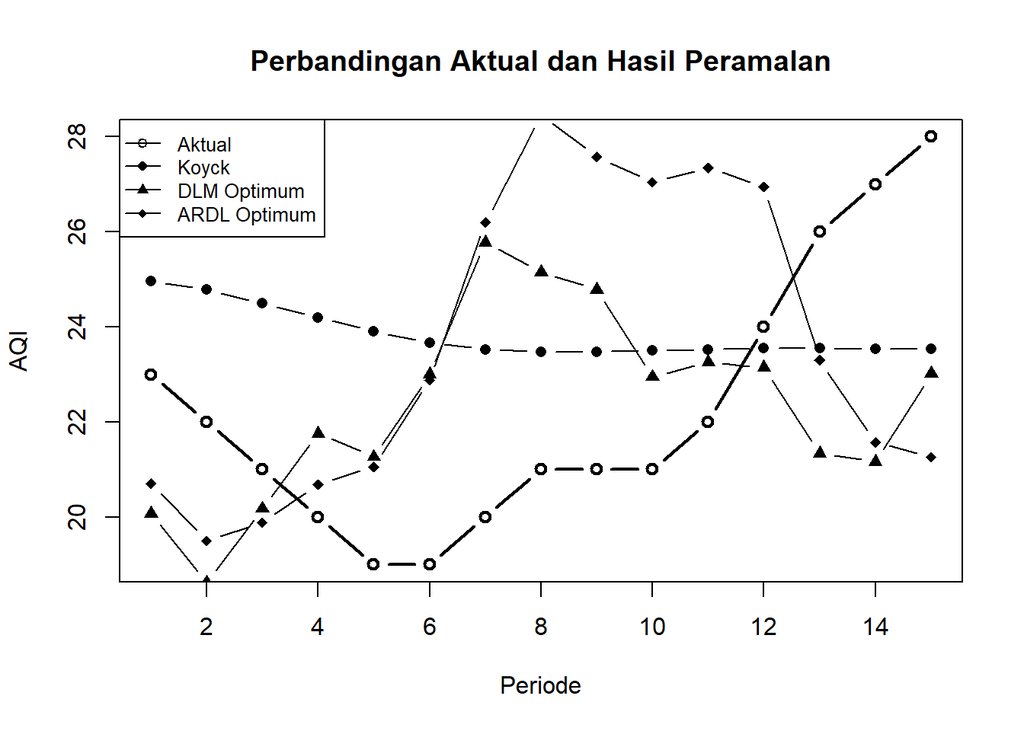

```r
plot(
  test$AQI,
  type = "b",
  pch = 1,
  lwd = 2,
  xlab = "Periode",
  ylab = "AQI",
  main = "Perbandingan Aktual dan Hasil Peramalan"
)

lines(fore.koyck$forecasts, type = "b", pch = 16)
lines(fore.dlm$forecasts, type = "b", pch = 17)
lines(fore.ardl$forecasts, type = "b", pch = 18)

legend(
  "topleft",
  legend = c("Aktual", "Koyck", "DLM Optimum", "ARDL Optimum"),
  lty = 1,
  pch = c(1, 16, 17, 18),
  cex = 0.8
)
```

# 10. Kesimpulan

Perbandingan akurasi menunjukkan bahwa **Koyck menghasilkan MAPE terkecil**, sehingga menjadi model dengan kinerja peramalan terbaik berdasarkan MAPE. Sementara itu, **ARDL optimum menghasilkan deviance terkecil**, sehingga memiliki kecocokan residual paling kecil pada data training di antara tiga model.

Pada uji asumsi `AQI ~ pm25 + L(pm25)`, nilai Durbin-Watson menunjukkan adanya indikasi autokorelasi positif dan uji Breusch-Pagan menunjukkan adanya heteroskedastisitas pada taraf 5%, sedangkan uji Shapiro-Wilk tidak menolak normalitas sisaan pada taraf 5%.